# The Bessembinder Correction: Fixing Observations in Compustat Global Data

Author

JKP data team

Published

July 12, 2026

## Overview

To improve the database, we apply the data correction from Bessembinder et al. (2023). The correction is applied to the Compustat daily security files and removes erroneous price observations before returns are calculated.

Since the correction is applied to Compustat, it can affect factors across the full database. The United States is affected much less, however, because the US series rely primarily on CRSP. In practice, the US long-short factors are almost unchanged relative to the current database, with the bulk of the changes appearing outside the United States.

## Background: What the Correction Does

The correction has two parts:

1. Rescaling decimal-shift errors in Compustat prices.
2. Dropping unreliable observations that cannot be safely repaired.

Bessembinder et al. (2023) show that raw Compustat security prices sometimes contain decimal-shift errors. In these cases, a price is recorded with the decimal point in the wrong place, so its level is off by a factor of 10, 100, or 1000 for one or more consecutive periods before returning to the correct scale. Because returns are computed from adjacent prices, one mis-scaled price creates two large, artificial returns that roughly offset each other.

The first part of the correction detects these decimal-shift errors using their spike-and-reversal pattern: the price jumps sharply away from its neighboring observations and then reverts.

- Single-period errors: an observation is flagged when its ratio to both the previous and next price is above 5, or below 1/5. Larger ratios identify larger decimal errors: thresholds above 50 or 500, and their low-side counterparts of 1/50 and 1/500, correspond to 100× and 1000× errors.
- Multi-period errors: the same reversal logic is applied over wider windows. This catches runs of consecutive mis-scaled observations when the values inside the run are stable relative to the surrounding price series.

Flagged decimal-shift errors are rescaled rather than discarded. The affected observation is divided or multiplied by the detected factor — 10, 100, or 1000 — so the price and the adjacent returns are repaired directly.

The second part of the correction removes problematic observations outright. These include:

- exact-zero prices;
- implausible jumps in shares outstanding;
- implausible jumps in market equity;
- implausible prices relative to market equity;
- problematic first or last observations in a security’s time series.

These observations are dropped rather than repaired, so this step can also change the underlying stock universe.

As an additional safeguard, we exclude daily returns greater than 1,000% (`ret` > 10). Any return exceeding this threshold after the Bessembinder correction is treated as a residual data error that could not be reliably repaired and is set to missing before entering the factor construction pipeline.

Separately, we recover returns for securities that never pay a dividend. Their total-return factor (`trfd`) is missing in Compustat, which would otherwise drop their returns. Wharton Research Data Services (no date) notes that “for those companies that never pay any dividends, the variable TRFD can appear to be missing throughout history, users can replace the missing value with value 1 in order to avoid unintentionally causing the calculated return series to be missing.” Following this guidance, we substitute `trfd` = 1 for these securities — whose price return equals total return in the absence of dividends — so their returns are kept rather than discarded.

### Modifications for Scale

To make the algorithm computationally feasible on a global daily dataset, we modify only the multi-period detection step that identifies runs of consecutively mis-scaled prices.

Bessembinder et al. (2023) apply the correction to monthly data, searching over all asymmetric combinations of up to three periods backward and three periods forward. Because we apply the correction to daily data, the number of observations increases by several orders of magnitude, making the original search computationally impractical. We therefore introduce two simplifications.

First, we replace the asymmetric search with symmetric windows. Rather than evaluating every backward/forward combination, we compare each day’s price with the prices n trading days before and after for a given window length n. Second, instead of searching every possible window length, we evaluate a priority set of horizons—1, 2, 3, 5, 10, and 21 trading days—covering intervals from one day to approximately one trading month. These horizons capture the vast majority of multi-period scaling errors while substantially reducing computation.

All other aspects of the procedure—including the single-period detection algorithm, the rescaling factors, and the observation removal criteria—are identical to those of Bessembinder et al. (2023).

## Scope of the change

The tables below show how the Compustat daily universe changes in the latest full pipeline run, split by JKP size group and reported separately for the United States and the rest of the world. We run the pipeline until December 2025.

Each count is a security-day observation:

### United States

|  | TOTAL | MEGA | LARGE | SMALL | MICRO | NANO | UNCLASSIFIED |
| --- | --- | --- | --- | --- | --- | --- | --- |
| Total Current | 129,799,940 | 9,046,916 | 11,876,257 | 18,200,954 | 41,441,052 | 43,407,719 | 5,827,042 |
| Corrections | 130,689 | 82 | 50 | 167 | 1,349 | 123,469 | 5,572 |
| Removals | 27,862,424 | 152,900 | 223,937 | 522,989 | 2,623,871 | 23,297,277 | 1,041,450 |
| Total Post-Correction | 101,937,516 | 8,894,016 | 11,652,320 | 17,677,965 | 38,817,181 | 20,110,442 | 4,785,592 |

### World ex-US

|  | TOTAL | MEGA | LARGE | SMALL | MICRO | NANO | UNCLASSIFIED |
| --- | --- | --- | --- | --- | --- | --- | --- |
| Total Current | 328,310,834 | 12,265,017 | 26,805,567 | 53,916,378 | 113,827,459 | 104,460,568 | 17,035,845 |
| Corrections | 9,764 | 101 | 61 | 135 | 617 | 7,859 | 991 |
| Removals | 44,881,965 | 104,699 | 302,973 | 1,017,353 | 6,589,972 | 36,120,208 | 746,760 |
| Total Post-Correction | 283,428,869 | 12,160,318 | 26,502,594 | 52,899,025 | 107,237,487 | 68,340,360 | 16,289,085 |

Region is assigned from the raw pre-correction daily files. As a result, essentially every observation can be attributed to either the United States or the rest of the world; the omitted residual with no mappable exchange is negligible, at less than 0.1%.

The main takeaway is that the correction is mostly a filtering step, not a rescaling step. Across both regions, there are 72.7 million removals compared with only 140 thousand rescaled observations. The removals are heavily concentrated among the smallest stocks: nano- and micro-cap observations account for most of the dropped observations, while mega- and large-cap observations are barely affected.

For the United States, this does not translate into a large change in the factor series, because US factors draw primarily on CRSP rather than Compustat. As a result, even though many US Compustat observations are removed, the impact on the US factor returns is small.

## Factor-Level Impact

We evaluate the correction using the `hml.parquet` output from the JKP portfolio pipeline. This file contains the long-short, or high-minus-low, return for each characteristic by country and month, under three weighting schemes: equal-weighted, value-weighted, and capped value-weighted.

We compare two full pipeline runs:

- a baseline run, with no Compustat correction applied;
- a corrected run, with the Bessembinder et al. (2023) correction applied.

The two outputs are joined on month-end date, country, and characteristic: `(eom, excntry, characteristic)`. We exclude Zimbabwe (ZWE) and Venezuela (VEN), since their returns are dominated by hyperinflation-era distortions. We also keep only country–characteristic pairs with more than 12 overlapping monthly observations. The resulting overlap window runs from January 1926 through December 2025 and covers 153 characteristics across 71 countries.

### Correlation with the Baseline

For each country × characteristic pair, we compute the time-series correlation between the baseline and corrected long-short returns. A correlation of 1 means the factor is unchanged by the correction. Lower correlations identify country-characteristic pairs where the correction moved the return series.

We now show histograms of the distribution of correlations.

**United States**

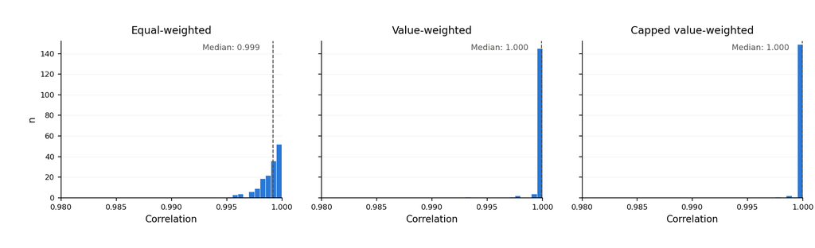

[output not shown]

**World ex-US**

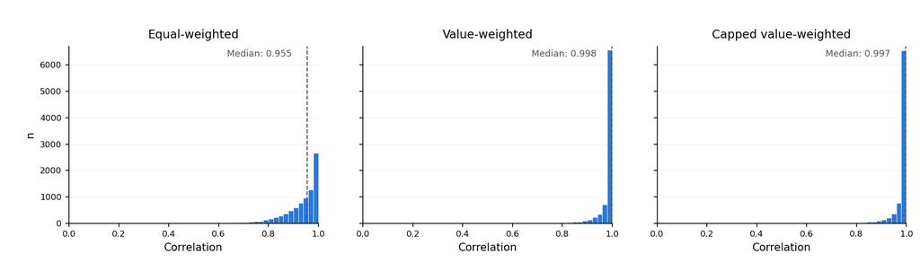

| Weighting | Pairs | Min | Q1 | Q2 / Median | Q3 | Max |
| --- | --- | --- | --- | --- | --- | --- |
| Equal-weighted | 8366 | 0.167 | 0.899 | 0.955 | 0.986 | 1.0 |
| Value-weighted | 8366 | 0.363 | 0.985 | 0.998 | 1.000 | 1.0 |
| Capped value-weighted | 8366 | 0.417 | 0.985 | 0.997 | 1.000 | 1.0 |

The US results confirm that the correction has almost no effect on the United States. Across all three weighting schemes, the correlations are essentially 1. This is expected, since US factors rely primarily on CRSP rather than Compustat.

For World ex-US, the median correlation sits slightly below 1. This is where the correction matters more, because the affected markets rely more directly on Compustat daily security data.

### Annualized Moments

The scatter grid below compares the annualized mean, volatility, and Sharpe ratio of each country × characteristic factor. The baseline value is on the x-axis and the corrected value is on the y-axis. The dashed 45-degree line marks exact agreement between the two runs.

Rows correspond to the three weighting schemes, while columns correspond to the three moments. US points are shown in red and World ex-US points in blue.

Points on the diagonal are effectively unchanged by the correction. Departures from the line show where the correction altered a factor’s return or risk profile. The US points remain tightly clustered around the diagonal, while the World ex-US points show the genuine impact of correcting the Compustat-sourced markets.

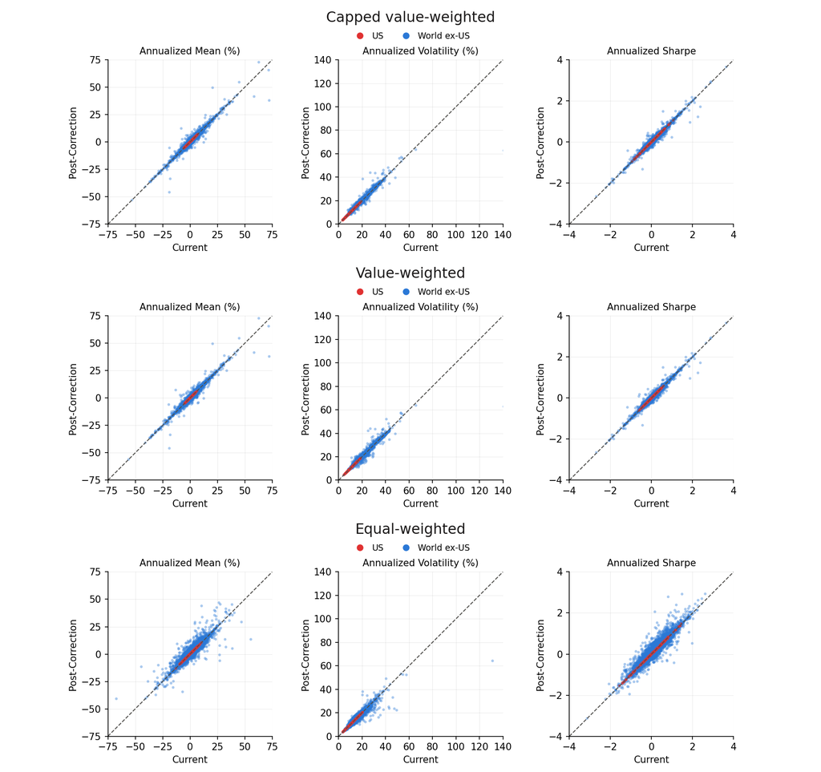

## Conclusion

The Bessembinder correction is primarily a filtering step: it removes far more observations than it rescales — roughly 72.7 million removals against 140 thousand price corrections — and those removals fall overwhelmingly on nano- and micro-cap stocks, leaving mega- and large-caps almost untouched.

US long-short returns are essentially unchanged — the median country–characteristic correlation with the uncorrected series is 0.999 to 1.000 across all three weighting schemes — because the US series draw primarily on CRSP rather than Compustat.

Non-US markets rely on Compustat directly, so the corrections pass through to their factors. The value-weighted factors barely move (median correlation 0.998), since the errors sit in the smallest stocks that carry little weight; the equal-weighted factors shift more (median 0.955), reflecting the cleanup of small-cap noise. About 95% of the 44.9 million non-US removals are nano- and micro-cap observations.

Overall, the correction improves data quality while leaving the economic drivers of the factors intact. For portfolios dominated by larger firms, the effect is negligible. For strategies with greater exposure to small stocks, the correction mainly removes noise from erroneous Compustat observations rather than changing true return patterns. The result is a cleaner and more reliable factor database.

## References

Bessembinder, H., Chen, T.-F., Choi, G. and Wei, K.C.J. (2023) ‘Long-Term Shareholder Returns: Evidence from 64,000 Global Stocks’, *Financial Analysts Journal*, 79(3). Available at: https://doi.org/10.1080/0015198X.2023.2188870.

Wharton Research Data Services (no date) *Computing Returns*. Available at: https://wrds-www.wharton.upenn.edu/pages/support/support-articles/compustat/global/computing-returns/ (Accessed: 10 July 2026).